# Proyecto Final Entrega 5

Diego Pintor, Miguel Morril, Aranzazú Rendón

16/4/2021

# 5. Modelos de Varianza

## 5.1 Volatilidad Histórica

La volatilidad historica muestras el riesgo historicos a través de un periodo actual hacia atrás. Se calcula midiendo las variaciones que han tenido los rendimientos del activo en cierto periodo de tiempo, el periodo lo elige el analista y por lo general suele ser anualizada.

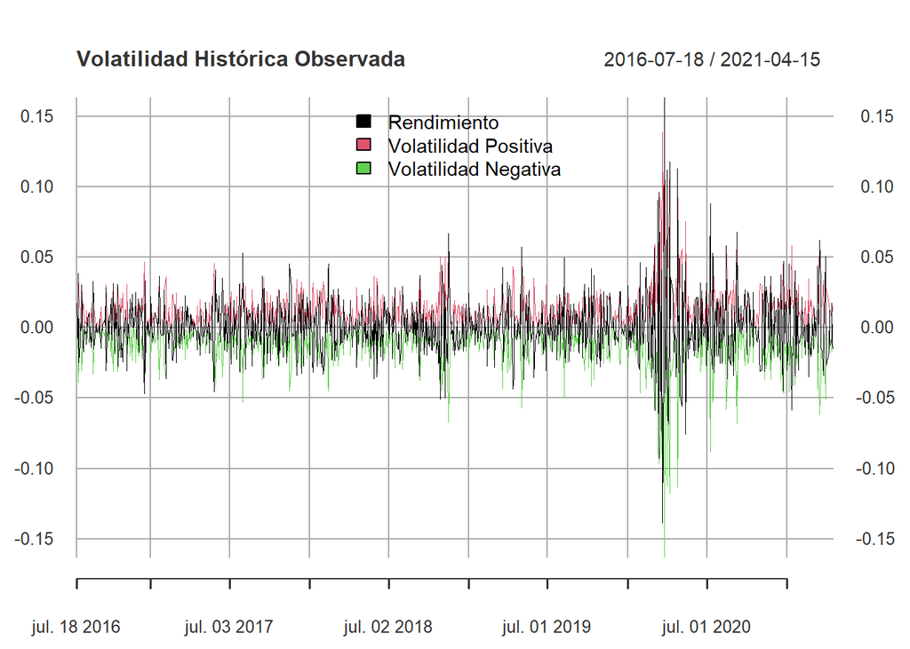

```r
Var_Hist<-rend**2
Vol_Hist<-sqrt(Var_Hist)
historica <-merge.xts(rend, Vol_Hist, -Vol_Hist)
names(historica)<-c("Rendimiento","Volatilidad Positiva","Volatilidad Negativa")
plot(historica, legend.loc = "top",main="Volatilidad Histórica Observada", lwd=.5)
```

## 5.2 Promedios Móviles

Estimación de la varianza diaria usando los últimos m días de información. Los pesos de cada rendimiento tienen un mismo impacto en la varianza.

Usa como estimación los m número de días y se calcula el valor optimo de m a través de la Raíz del Error Medio Cuadrado “RMSE”, usando el menor RMSE para la estimación.

Probamos diferentes estimaciones de n numeros de días para poder determinar el modelo que mejor se ajuste a la varianza real.

```r
mavback <- function(x,n){ stats::filter(x, c(0, rep(1/n,n)), sides=1) }
```

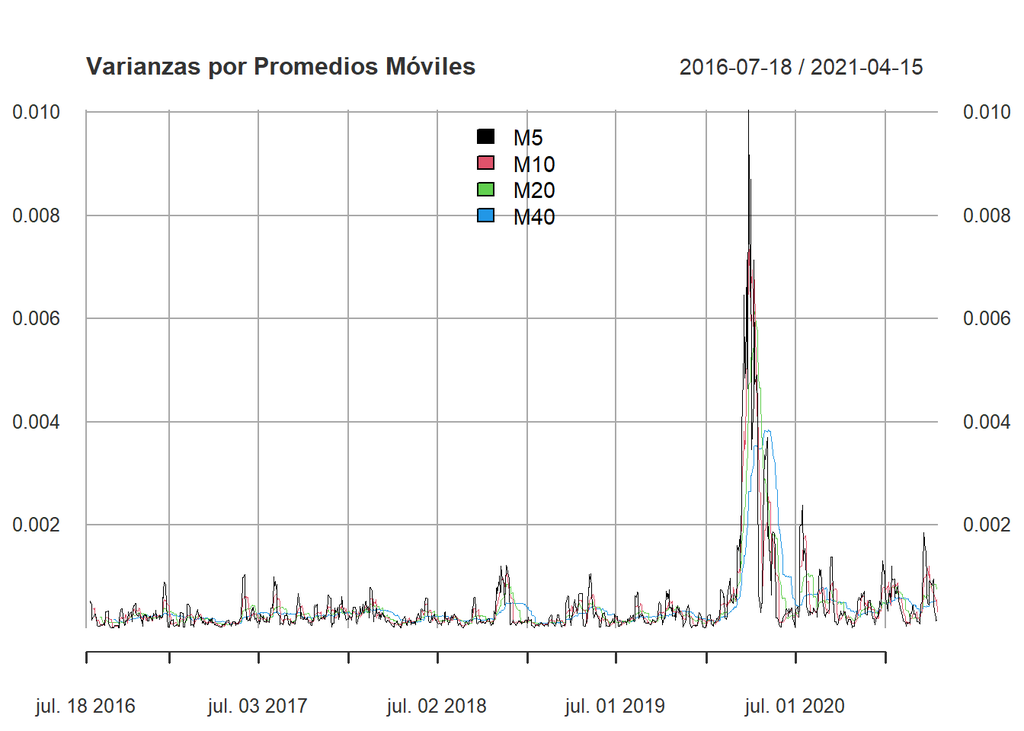

```r
Var_Est5 <- xts(mavback(Var_Hist, n=5), order.by = date(Var_Hist))
Var_Est10 <- xts(mavback(Var_Hist, n=10), order.by = date(Var_Hist))
Var_Est20 <- xts(mavback(Var_Hist, n=20), order.by = date(Var_Hist))
Var_Est40 <- xts(mavback(Var_Hist, n=40), order.by = date(Var_Hist))
Var_Est <- merge.xts(Var_Est5, Var_Est10, Var_Est20, Var_Est40)
Var_Est <- merge.xts(Var_Est5, Var_Est10, Var_Est20, Var_Est40)
names(Var_Est) <- c("M5","M10","M20","M40")
plot(Var_Est, legend.loc="top", main = "Varianzas por Promedios Móviles", lwd=.5)
```

Graficamos los modelos a m dias

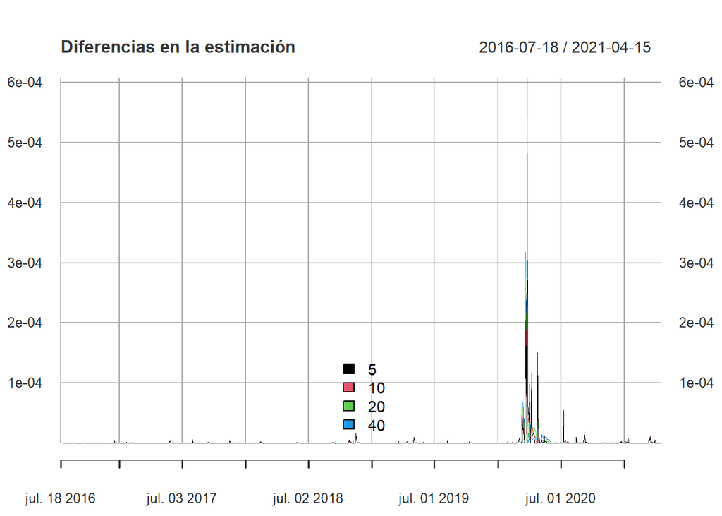

Obtenemos los diferenciales de cada modelo de m, para asi elegir el menos de todos.

```
##           RMSE
## 5  0.001303156
## 10 0.001265175
## 20 0.001295134
## 40 0.001338997
```

Obtenemos el RMSE menor, y ese va a ser nuestra m que vamos a usar para que se ajuste mejor la varianza estimada a la real.

```
## [1] 10
```

Resulta que el valor del M optimo será m 10 De todas las estimaciones vamos a usar la optima y compararla con la real

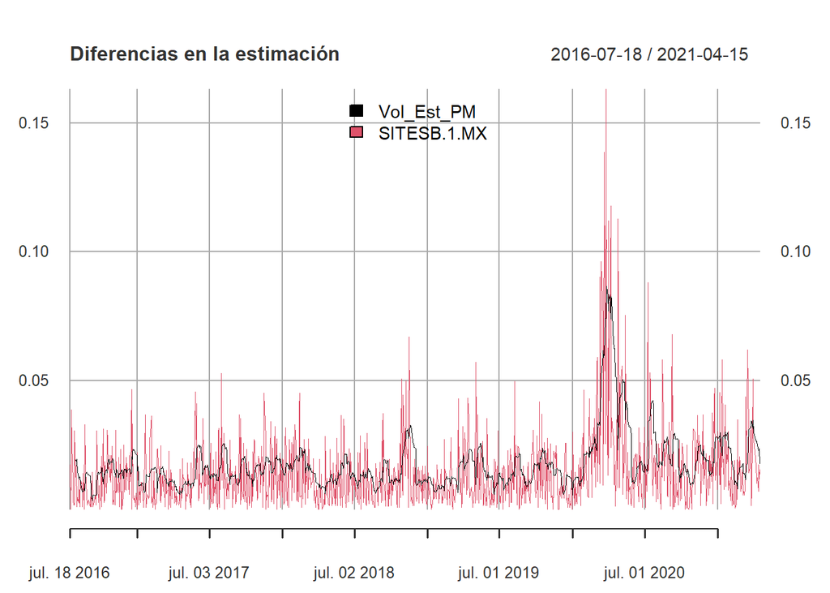

```r
plot(merge.xts(Vol_Est_PM,Vol_Hist),legend.loc="top" ,main="Diferencias en la estimación", lwd=.5)
```

## 5.3 Promedios Móviles de Ponderación Exponencial (EWMA)

Este modelo se asemeja demasiado al PM, la diferencia es que en este las ponderaciones se hacen a cada uno de los terminos que reprentan los rendimientos al cuadrado, los cuales van disminuyendo a una tasa de lamda, asi otorgando mayor peso a las estimaciones recientes y haciendo menos significantes las de menor peso. Este modelo posee la propiedad de ser recursivo lo que significa que se autoregula, no obstante depende de la periodicidad de los datos determinada por lamda que suele ser entre .94 y .97.

Aqui voy a decir que el parametro del modelo se estima con maxima verosimilitud y eso consiste en maximizar la funcion de merosimilitud

```r
n <- nrow(Var_Hist)
Var_Est <- matrix(0,n-1,1)
a <- seq(0.1,0.99,by=0.01)
Var_Est[1,1] <- Var_Hist[1,1]
Func <- matrix(0,n-1,1)
Resultados <- matrix(0,length(a),2)
colnames(Resultados) <- c('Lambda', 'Sum_FMV')
j <- 0
for (L in a) {
  for (i in 2:(n-1)) {
    Var_Est[i,1] <- (1-L)*Var_Hist[i-1,1] + L*Var_Est[i-1,1] #modelo EWMA
    Func[i,1] <- - log(Var_Est[i-1,1]) - Var_Hist[i-1,1] / Var_Est[i-1,1]
  }
  j <- j+1
  FMaxAct <- sum(Func)
  Resultados[j,1] <- L
  Resultados[j,2] <- FMaxAct
}
```

Vamos a extraer el valor optimo de Lambda

```r
L_opt <- Resultados[order(Resultados[,'Sum_FMV'], decreasing = TRUE),]
L_opt <- as.numeric(L_opt[1,1])
L_opt
```

```
## [1] 0.92
```

Aqui yo puedo escribir mi modelo con unn valor especifico de Lambda

Ahora hagamos estimaciones pasadas, usando EWMA con el L_opt para ver que tal funciona el modelo

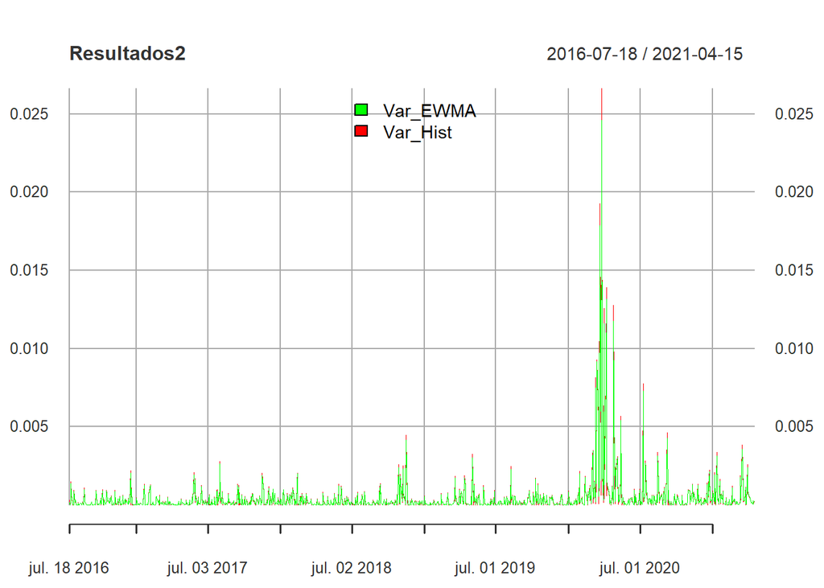

```r
Var_Est_EWMA <- xts(emaTA(Var_Hist, lambda = L_opt), order.by= date(rend))
Resultados2 <- merge.xts(Var_Est_EWMA, Var_Hist)
names(Resultados2) <- c('Var_EWMA','Var_Hist')
plot(Resultados2, legend.loc = 'top', lwd=c(.4,.8), col=c('green','red'))
```

## 5.4 Modelos de Heterocedasticidad Autorregresiva ### 5.4.1 ARCH

ARCH es la Heterocedasticidad Condicional Auto-Regresiva, que considera una Varianza a largo plazo, este modelo considera que para determinar la varianza en el tiempo t, necesitamos conocer la varianza y el rendimiento en el tiempo t-1, gracias a la varianza a largo plazo este modelo permite estimaciones más a futuro.

Prueba de Independencia de los Precios

```r
independencia <- Box.test(precio,lag=1,type="Ljung-Box",fitdf = 0)
independencia$statistic
```

```
## X-squared
##  1175.317
```

Como el estadístico de la prueba de Box es mayor que 23.20925, se rechaza la H0 y se acepta la Hipótesis Alternativa, los precios son dependientes.

Generando Modelos ARCH de 1 a 5 rezagos.

```r
AICoptimo
```

```
##       AIC       AIC       AIC       AIC       AIC
## -5.088493 -5.178225 -5.218681 -5.231708 -5.237671
```

El mejor modelo es el ARCH con 5 rezagos

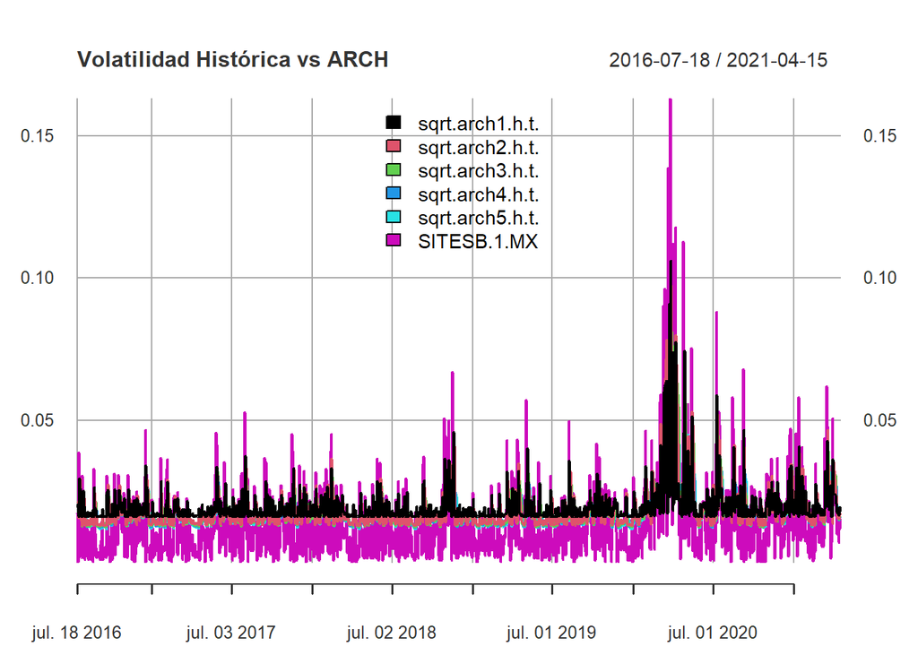

```r
comp <- merge.xts(sqrt(arch1@h.t),sqrt(arch2@h.t),sqrt(arch3@h.t),sqrt(arch4@h.t),sqrt(arch5@h.t),Vol_Hist,names(c("ARCH 5","Volatilidad Histórica")))
plot(comp,legend.loc="top",main="Volatilidad Histórica vs ARCH",lw=.5)
```

### 5.4.2 GARCH

GARCH es un modelo muy similar a GARCH con la diferencia que este considera el parametro de **q** estimaciones previas que se hayan efectuado sobre la varianza.

Generando Modelos GARCH de 1 a 5 rezagos de p y q.

```r
AICoptimo
```

```
##       AIC       AIC       AIC       AIC       AIC
## -5.261546 -5.260790 -5.257187 -5.256653 -5.256212
```

El mejor modelo es el GARCH con 1 rezago

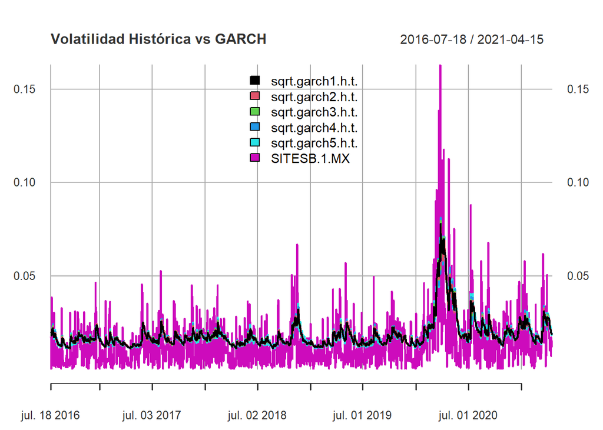

```r
comp <- merge.xts(sqrt(garch1@h.t),sqrt(garch2@h.t),sqrt(garch3@h.t),sqrt(garch4@h.t),sqrt(garch5@h.t),Vol_Hist,names(c("ARCH 5","Volatilidad Histórica")))
plot(comp,legend.loc="top",main="Volatilidad Histórica vs GARCH",lw=.5)
```